## Introduction

Today, I’ll be attempting to use two datasets from [Kaggle](https://www.kaggle.com/aaron7sun/stocknews), the first being a Reddit news dataset containing the top 25 daily headlines from [Reddit WorldNews Channel (/r/worldnews)](https://www.reddit.com/r/worldnews/) from 2008-2016. The second dataset contains the opening and closing values of the DOW Jones Index for the same period of 2008-2016. My goal for the project is to use Natural Language Processing techniques to predict whether the stock market will rise or fall based on the headlines for a particular day.

```r
library(readr)
library(dplyr)
```

```r
library(ggplot2)
library(stringi)
library(tokenizers)
library(smodels)
library(keras)
library(Matrix)
library(methods)
```

# Preprocessing

Let’s read in our data from the CSV files from Kaggle.

```r
news <- read_csv("Combined_News_DJIA.csv")
dow <- read_csv("DJIA_table.csv")
```

First, let’s join both tables based on the date so that we have one table to work with.

```r
dow$Date <- as.Date(dow$Date)
news$Date <- as.Date(news$Date)

data <- merge(dow, news, by = "Date")
```

Now that we have our data in one table, let’s go ahead and combine all of the top 25 headlines into one text blob.

```r
data$all <- paste(data$Top1, data$Top2, data$Top3, data$Top4, data$Top5, data$Top6,
                  data$Top7, data$Top8, data$Top9, data$Top10, data$Top11, data$Top12,
                  data$Top13, data$Top14, data$Top15, data$Top16, data$Top17, data$Top18,
                  data$Top19, data$Top20, data$Top21, data$Top22, data$Top23, data$Top24,
                  data$Top25, sep=' <s> ')

# Remove punctuations from text
data$all <- gsub('b"|b\'|\\\\|\\"', "", data$all)
data$all <- gsub("([<>])|[[:punct:]]", "\\1", data$all)
```

Now that we have our headline text data as we’d like, let’s go ahead and calculate the difference between the closing and opening price on the DOW index for a given day.

```r
# Calculate the difference between the closing and opening index for a given day
data$Delta <- dow$Close - dow$Open
```

Now, let’s throw away all the data that we don’t need.

```r
data <- data[, c('Date', 'all', 'Delta', 'Label')]
head(data, 1)
```

```
##         Date
## 1 2008-08-08
##                                                                                                                                                                                                                                                                                                          …
## 1 Georgia downs two Russian warplanes as countries move to brink of war <s> BREAKING Musharraf to be impeached <s> Russia Today Columns of troops roll into South Ossetia footage from fighting YouTube <s> Russian tanks are moving towards the capital of South Ossetia which has reportedly been compl…
##      Delta Label
## 1 25.12891     0
```

Note that there is a column called **Label** in which a 1 indicates that the Dow Jones index stayed the **same or rose** for a given day, and a 0 indicates that the Dow Jones index **fell**.

```r
training_data <- sample_frac(data, 0.75)
data$train_id = ifelse(data$Date %in% training_data$Date, "train", "test")
```

## Building a glmnet model

Let’s take all of the words the combined texts, tokenize them and put them into a matrix.

```r
token_list <- tokenize_words(data$all)
token_df <- term_list_to_df(token_list)

X <- term_df_to_matrix(token_df, min_df = 0.05, max_df = 1, scale = FALSE)
y <- data$Delta

X_train <- X[data$train_id == "train",]
X_valid <- X[data$train_id == "test",]
y_train <- y[data$train_id == "train"]
y_valid <- y[data$train_id == "test"]
```

Finall, using **glmnet** let’s construct our model.

```r
library(glmnet)
```

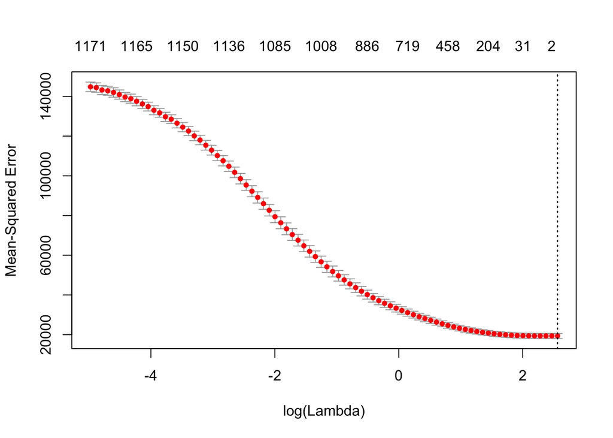

```r
model <- cv.glmnet(X_train, y_train)
plot(model)
```

Let’s predict values and see what accuracy we end up with.

```r
data$Delta_pred <- predict(model, newx = X, type = "response", s=model$lambda[30])
#tapply(data$Label_pred == data$Label, data$train_id, mean)
sqrt(tapply((data$Delta_pred - data$Delta)^2, data$train_id, mean))
```

```
##      test     train
## 183.31015  84.94153
```

We get an RMSE of ~180 using tokenization. Let’s have a look at the other models get us.

### Using bi-grams

Let’s use bigrams to see if we can get a better prediction rate.

```r
token_list <- tokenize_ngrams(data$all, n_min = 1, n = 2)
token_df <- term_list_to_df(token_list)
X <- term_df_to_matrix(token_df, min_df = 0.01, max_df = 0.90, scale = TRUE)
y <- data$Delta
```

```r
X_train <- X[data$train_id == "train",]
X_valid <- X[data$train_id == "test",]
y_train <- y[data$train_id == "train"]
y_valid <- y[data$train_id == "test"]

set.seed(1)
sample(colnames(X), 25)
```

```
##  [1] "the german"      "raids"           "flooding"
##  [4] "concerned about" "gave"            "turkish prime"
##  [7] "attempted to"    "2013 s"          "nearby"
## [10] "earthquake"      "video of"        "issue"
## [13] "arrest s"        "cable"           "adoption"
## [16] "the air"         "damaging"        "northeast"
## [19] "page"            "enters"          "the mexican"
## [22] "the people"      "once again"      "running"
## [25] "broke"
```

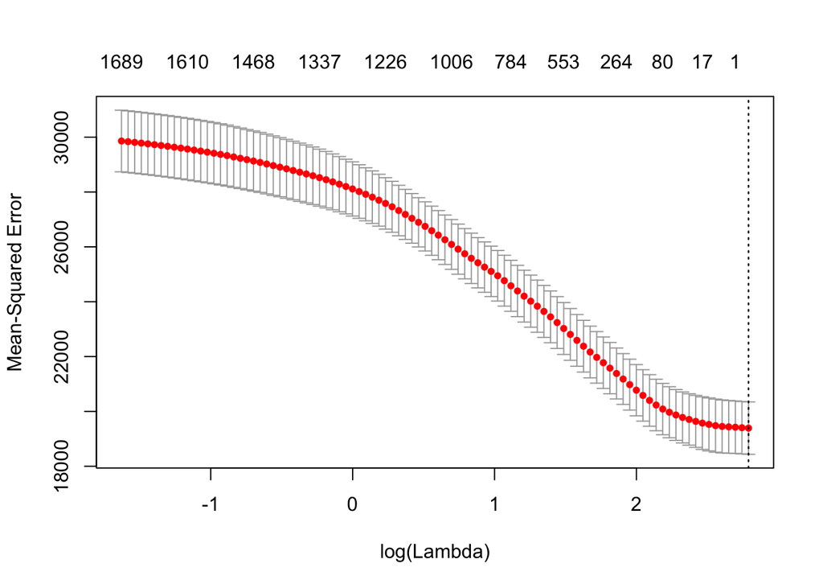

```r
model <- cv.glmnet(X_train, y_train, nfolds = 5, family = "gaussian")
plot(model)
```

```r
data$Delta_pred_bigrams <- predict(model, newx = X, s=model$lambda[30])
sqrt(tapply((data$Delta_pred_bigrams - data$Delta)^2, data$train_id, mean))
```

```
##      test     train
## 154.58068  90.15058
```

### Character shingles

How about considering character shingles of our headlines? Let’s see how our model does using this new strategy.

```r
token_list <- tokenize_character_shingles(data$all, n_min = 1, n = 3, strip_non_alphanum = FALSE)

token_df <- term_list_to_df(token_list)

X <- term_df_to_matrix(token_df, min_df = 0.01, max_df = 0.90,
                       scale = TRUE)

y <- data$Delta

X_train <- X[data$train_id == "train",]
X_valid <- X[data$train_id == "test",]
y_train <- y[data$train_id == "train"]
y_valid <- y[data$train_id == "test"]

# Let's see what the character shingles look like
set.seed(1)
sample(colnames(X), 25)
```

```
##  [1] "iva"  "tir"  "mie"  "1 h"  "vio"  "v h"  "b g"  "oit"  "900"  "eb"
## [11] "pai"  "ory"  "apr"  "kid"  "8 h"  "nym"  "ckn"  "afp"  "kh"   "lst"
## [21] " \nm" "sli"  "uru"  "lla"  "acr"
```

```r
model <- cv.glmnet(X_train, y_train, nfolds = 5, family = "gaussian", alpha = 0.8)
```

```r
data$Delta_pred_charshingles <- predict(model, newx = X, type = "response", s=model$lambda[30])
sqrt(tapply((data$Delta_pred_charshingles - data$Delta)^2, data$train_id, mean))
```

```
##     test    train
## 154.2839 102.2436
```

It seems like character shingles and bigrams give us a similar RMSE. Sad :(

### Word embeddings and neural nets

To remind you of what a word embedding is (from Dr. Arnold’s slides): ‘A word embedding is nothing more than a compression of a one-hot representation and a dense hidden layer in a neural network.’

```r
words <- tokenize_words(data$all)

# vocabulary of terms we will allow in the model will be the top 10000 words in the headlines
vocab <- top_n(count(data_frame(word = unlist(words)), word), n = 10000)$word
head(vocab, 100)
```

```
##   [1] "0"           "000"         "08"          "1"           "10"
##   [6] "100"         "1000"        "10000"       "100000"      "1000s"
##  [11] "1000yearold" "100m"        "100s"        "101"         "103"
##  [16] "105"         "106"         "107"         "108"         "109"
##  [21] "10m"         "10th"        "10year"      "10yearold"   "11"
##  [26] "110"         "11000"       "112"         "114"         "115"
##  [31] "116"         "11th"        "11year"      "11yearold"   "12"
##  [36] "120"         "1200"        "12000"       "120000"      "121"
##  [41] "122"         "123"         "124"         "125"         "127"
##  [46] "129"         "12yearold"   "13"          "130"         "1300"
##  [51] "13000"       "130000"      "133"         "135"         "138"
##  [56] "13bn"        "13th"        "13yearold"   "14"          "140"
##  [61] "1400"        "140000"      "14yearold"   "15"          "150"
##  [66] "1500"        "15000"       "150000"      "153"         "154"
##  [71] "155"         "15bn"        "15th"        "15yearold"   "16"
##  [76] "160"         "1600"        "16000"       "160000"      "161"
##  [81] "165"         "16yearold"   "17"          "170"         "1700"
##  [86] "17000"       "17th"        "17yearold"   "18"          "180"
##  [91] "1800"        "18000"       "182"         "185"         "18th"
##  [96] "18yearold"   "19"          "190"         "1915"        "1930s"
```

With this vocabulary, we next create numeric indicies, throwing away terms not in our vocabulary.

```r
id <- lapply(words, function(v) match(v, vocab))
id <- lapply(id, function(v) v[!is.na(v)])
id[1:3]
```

```
## [[1]]
##   [1]  4328  3219 10106  8413 10521   926  2491  6422  9836  1555  6758
##  [12] 10503  8422  1522  6472  9836  1203  8422  8412  9838  6758 10034
##  [23]  8333  5217  9063  6899  4094  4195  3956 10845  8422  8413  9602
##  [34]   871  6429  9906  9729  1755  6758  9063  6899 10632  4617  8101
##  [45]  1229  2249  2943  1674  4329   921  4009  8422   523  1971  7853
##  [56] 10700  5008 10142  6776  8513  9763  5286  8845   338  9778 10814
##  [67]  6791 10535  7853   719  9745  3148  6678  8422    65  8413  9602
##  [78]  4627  3531  9063  6899 10634  4328  8808  3210 10106  8413  5365
##  [89]  8422  1522  4328  5230  9063  6899  8412 10515  5319 10762  5207
## [100]  6803  8848  8422  9729  3493 10009   871  6678  1665   338  8742
## [111]  4617  1229  8672  9836   251    35 10818  1665 10667  1203  5472
## [122]  5870   798  5441  1220  9745  3915  5792  5319  8422  4329 10034
## [133]  8205  4195  8422  1755  5686  8719  4878  7139  5502 10399  8422
## [144]  3006  9729 10300  4328  4097 10503 10700  8412  8422  8251  4360
```

[output cut: 83 more lines]

Not every headline will contain the same number of words. To deal with this we pick a particular reference length, truncating longer sentences and padding shorter sentences with zeros.

```r
X <- pad_sequences(id, maxlen = 100)
X[1:5,]
```

```
##      [,1]  [,2] [,3]  [,4] [,5] [,6] [,7] [,8]  [,9] [,10] [,11] [,12]
## [1,] 6758  6239 4842  8422 9763 5286  338 1664  2707  9729  3611 10210
## [2,] 9729 10300 1250  9729 4329  549 8422 3148  6674  1264 10094  6569
## [3,] 8164  9836 4328 10535 8272 8422 4397  421 10300  6758  5977   338
## [4,] 5090 10506 8422 10650 8416 8164 9836 4328 10535  8272  8422  3420
## [5,] 2569   139 2709  3320 8422 4328 2475 8704  1089  8416 10300  8032
##      [,13] [,14] [,15] [,16] [,17] [,18] [,19] [,20] [,21] [,22] [,23]
## [1,]  4617   847  6597  8475   538  5270  5009  7654   985  5327  6696
## [2,]  8413  6657  4329  9740   871  6440  6373 10393  8422  8284   871
## [3,]  8690  5009  7736  5327  5189  5009  9729  1827  8003  8422  8412
## [4,]  3780  1674   165  8422 10300  4872  6289  9049  5009  4328  4937
## [5,]  4097 10818 10743  6602  4494  8422 10503  5009  9729  1827  5286
##      [,24] [,25] [,26] [,27] [,28] [,29] [,30] [,31] [,32] [,33] [,34]
## [1,]  7588  8422  4328 10667 10701     7  9019  4195  5274  9836  4687
## [2,]  9256  4383  6803  5009  6359  1725  1220  7351  6461   338  1485
```

[output cut: 39 more lines]

```r
y <- data$Delta

X_train <- X[data$train_id == "train",]
X_valid <- X[data$train_id == "test",]
y_train <- y[data$train_id == "train"]
y_valid <- y[data$train_id == "test"]
```

Let’s build our neural network now.

```r
model <- keras_model_sequential()

model %>%
  layer_dense(units = 256, input_shape = ncol(X_train)) %>%
  layer_activation(activation = "relu") %>%
  layer_dense(units = 256) %>%
  layer_activation(activation = "relu") %>%
  layer_dense(units = 256) %>%
  layer_activation(activation = "relu") %>%
  layer_dense(units = 1)

model
```

```
## Model
## ___________________________________________________________________________
## Layer (type)                     Output Shape                  Param #
## ===========================================================================
## dense_1 (Dense)                  (None, 256)                   25856
## ___________________________________________________________________________
## activation_1 (Activation)        (None, 256)                   0
## ___________________________________________________________________________
## dense_2 (Dense)                  (None, 256)                   65792
## ___________________________________________________________________________
## activation_2 (Activation)        (None, 256)                   0
## ___________________________________________________________________________
## dense_3 (Dense)                  (None, 256)                   65792
## ___________________________________________________________________________
## activation_3 (Activation)        (None, 256)                   0
## ___________________________________________________________________________
## dense_4 (Dense)                  (None, 1)                     257
## ===========================================================================
## Total params: 157,697
## Trainable params: 157,697
## Non-trainable params: 0
## ___________________________________________________________________________
```

Let’s set the loss for our model (the thing we want to minimize) to mean squared error.

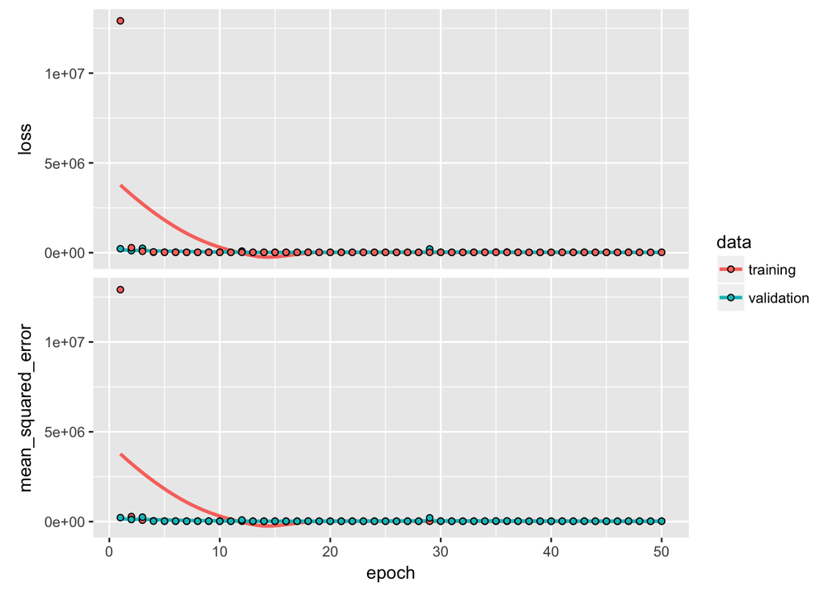

```r
model %>% compile(
  loss = 'mse',
  optimizer = optimizer_rmsprop(),
  metrics = c('mse')
)

history <- model %>% fit(X_train, y_train, epochs = 50, validation_data = list(X_valid, y_valid))

plot(history)
```

```r
data$Delta_pred_embedding <- predict(model, X)
sqrt(tapply((data$Delta_pred_embedding - data$Delta)^2, data$train_id, mean))
```

```
##     test    train
## 155.1132 124.2026
```

### Convolutional neural nets

Let’s use a CNN to see if we get better results.

```r
model <- keras_model_sequential()
model %>%
  layer_embedding(
    input_dim = length(vocab) + 1,
    output_dim = 50,
    input_length = ncol(X)
    ) %>%

  layer_conv_1d(filters = 128, kernel_size = c(5)) %>%
  layer_global_average_pooling_1d() %>%
  layer_dropout(rate = 0.2) %>%

  layer_dense(256) %>%
  layer_activation("relu")%>%
  layer_dense(1)

model %>% compile(
  loss = "mse",
  optimizer = optimizer_rmsprop(),
  metrics = c("mse")
)

model
```

```
## Model
## ___________________________________________________________________________
## Layer (type)                     Output Shape                  Param #
## ===========================================================================
## embedding_1 (Embedding)          (None, 100, 50)               543700
## ___________________________________________________________________________
## conv1d_1 (Conv1D)                (None, 96, 128)               32128
## ___________________________________________________________________________
## global_average_pooling1d_1 (Glob (None, 128)                   0
## ___________________________________________________________________________
## dropout_1 (Dropout)              (None, 128)                   0
## ___________________________________________________________________________
## dense_5 (Dense)                  (None, 256)                   33024
## ___________________________________________________________________________
## activation_4 (Activation)        (None, 256)                   0
## ___________________________________________________________________________
## dense_6 (Dense)                  (None, 1)                     257
## ===========================================================================
## Total params: 609,109
## Trainable params: 609,109
## Non-trainable params: 0
## ___________________________________________________________________________
```

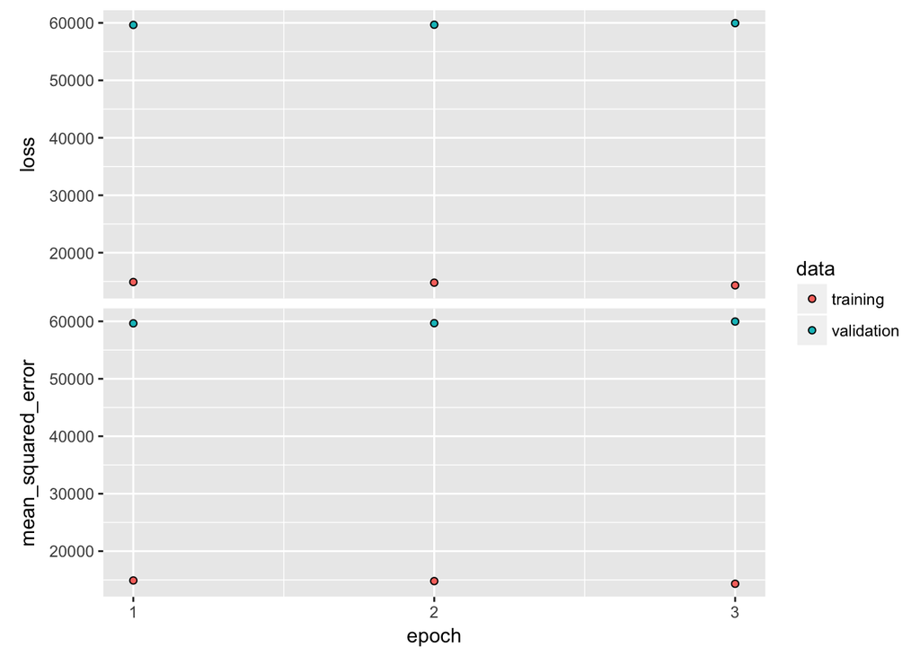

```r
history <- model %>% fit(X_train, y_train, batch_size = 32,
              epochs = 3,
              validation_split = 0.1)

plot(history)
```

```r
data$Delta_pred_cnn <- predict(model, X)
sqrt(tapply((data$Delta_pred_cnn - data$Delta)^2, data$train_id, mean))
```

```
##     test    train
## 149.5899 134.8924
```

## Transfer Learning

Let’s have a look at transfer learning to see if this gets us better results. We’ll use the fasttextM library for this.

```r
y <- data$Label
text <- data[stri_length(data$all) > 100,]
words <- tokenize_words(text$all)
vocab <- top_n(count(data_frame(word = unlist(words)), word),
                n = 10000)$word
id <- lapply(words, function(v) match(v, vocab))
id <- lapply(id, function(v) v[!is.na(v)])
X <- pad_sequences(id, maxlen = 100)

X_words <- matrix(c("", vocab)[X + 1], nrow = nrow(X))
```

```r
library(fasttextM)
ft_load_model("en")
```

```r
X_embed <- ft_embed(as.vector(X_words), lang = "en")
X_embed[is.na(X_embed)] <- 0
X_embed <- array(X_embed, dim = c(nrow(X_words), ncol(X_words), 100))
```

```r
model <- keras_model_sequential()
model %>%
  layer_lstm(units = 64,
             dropout = 0.2,
             recurrent_dropout = 0.2,
             return_sequences = FALSE,
             input_shape = dim(X_embed)[-1]) %>%
  layer_dense(units = 1, activation = 'relu')
```

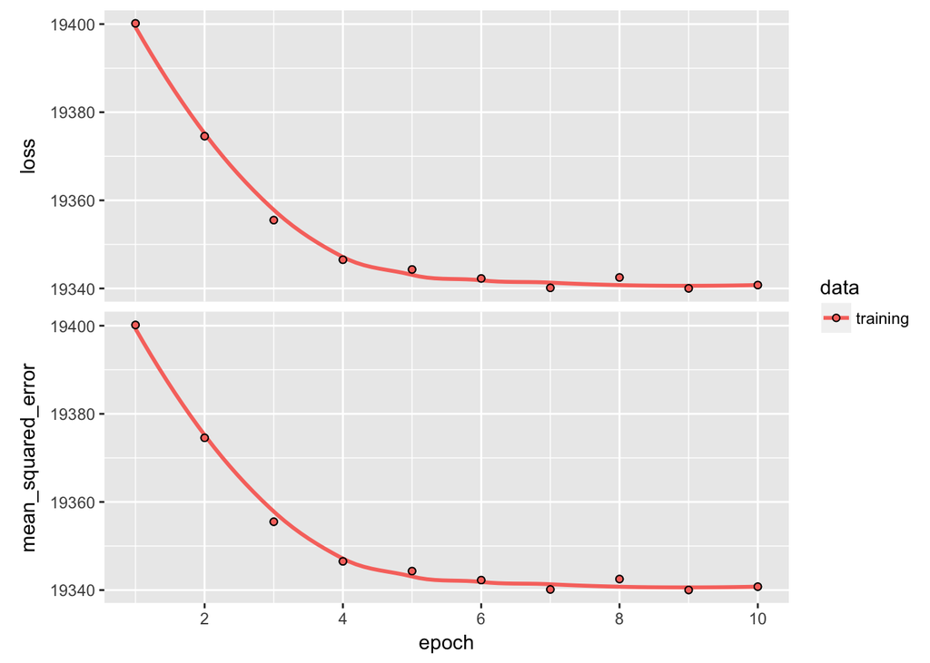

```r
model %>% compile(loss = 'mse',
                  optimizer = 'adam',
                  metrics = c('mse'))

X_train <- X_embed[data$train_id == "train",,]
X_valid <- X_embed[data$train_id == "valid",,]
y <- data$Delta
y_train <- y[data$train_id == "train"]
y_valid <- y[data$train_id == "valid"]

history <- model %>% fit(X_train, y_train,
              batch_size = 32,
              epochs = 10,
              validation_data = list(X_valid, y_valid))

plot(history)
```

```r
data$Delta_pred_transfer <- predict(model, X_embed)
sqrt(tapply((data$Delta_pred_transfer - data$Delta)^2, data$train_id, mean))
```

```
##     test    train
## 147.5274 139.0472
```

It seems as if transfer learning gives us the best RMSE, but looking at the data paints a different picture.

```r
head(data, 3)
```

```
##         Date
## 1 2008-08-08
## 2 2008-08-11
## 3 2008-08-12
##                                                                                                                                                                                                                                                                                                          …
## 1 Georgia downs two Russian warplanes as countries move to brink of war <s> BREAKING Musharraf to be impeached <s> Russia Today Columns of troops roll into South Ossetia footage from fighting YouTube <s> Russian tanks are moving towards the capital of South Ossetia which has reportedly been compl…
## 2                                                                                                                                                                                                                                                                                                        …
## 3                                                                                                                                                                                                       Remember that adorable 9yearold who sang at the opening ceremonies That was fake too <s> Russia e…
##       Delta Label train_id          1          1         1
## 1  25.12891     0    train   6.694742   8.576808  39.52275
## 2 217.23047     1    train 120.645165  92.717308  97.18917
## 3 238.66016     0    train 157.233635 139.257040 114.17974
##   Delta_pred_embedding Delta_pred_cnn Delta_pred_transfer
## 1           143.794617       22.62252            7.408223
## 2             1.115053       29.17292            7.468632
## 3           -68.490166       35.38612            7.450417
```

While trying to minimize RMSE, the transfer learning method predicts the majority of our delta values to be positive.

### The moment of truth

Let’s find of our above models was the best. We’ll compare the Label (where 0 indicates a decrease in the market and 1 indicates the index staying the same or rising) against the predicted value of Delta.

```r
# Word frequency glmnet model
delta_pred_label <- ifelse(data$Delta_pred >= 0, 1, 0)
tapply(delta_pred_label == data$Label, data$train_id, mean)
```

```
##      test     train
## 0.5150905 0.4812332
```

```r
# Bigram glmnet model
delta_bigram_label <- ifelse(data$Delta_pred_bigrams >= 0, 1, 0)
tapply(delta_bigram_label == data$Label, data$train_id, mean)
```

```
##      test     train
## 0.4969819 0.4892761
```

```r
# Character shingles glmnet model
delta_shingle_label <- ifelse(data$Delta_pred_charshingles >= 0, 1, 0)
tapply(delta_shingle_label == data$Label, data$train_id, mean)
```

```
##      test     train
## 0.5352113 0.5087131
```

```r
# Word embedding + Neural net model
delta_embedding_label <- ifelse(data$Delta_pred_embedding >= 0, 1, 0)
tapply(delta_embedding_label == data$Label, data$train_id, mean)
```

```
##      test     train
## 0.5090543 0.4537534
```

```r
# CNN model
delta_cnn_label <- ifelse(data$Delta_pred_cnn >= 0, 1, 0)
tapply(delta_cnn_label == data$Label, data$train_id, mean)
```

```
##      test     train
## 0.5472837 0.5308311
```

```r
# Transfer learning
delta_transfer_label <- ifelse(data$Delta_pred_transfer >= 0, 1, 0)
tapply(delta_transfer_label == data$Label, data$train_id, mean)
```

```
##      test     train
## 0.5472837 0.5315013
```

It seems as if the CNN and transfer learning models were the best of the lot, with accuracies of close to 55%.

## Closing remarks

- The headline data that I used is pretty general since it encapsulates a wide range of topics that are not relevant to stock markets. Using financial news would definitely give us better results.
- Since financial news may not occur as often as political news, it is difficult for a machine learning model to sift through the noise and pick our relevant words that might cause the Dow Jones index to rise/fall.

## Fun fact!

It turns out that this strategy may have been used by hedge funds. [From 2008-2010, it was observed that Berkshire-Hathaway stock would rise every time an Anne Hathaway movie would release](https://www.huffingtonpost.com/dan-mirvish/the-hathaway-effect-how-a_b_830041.html). This could result from hedge funds using techniques similar to the ones I’ve used above.